# The U.S. Constitution

POLS 2311: Government of the United States

## Agenda

- Purpose: What Do Constitutions Accomplish?
- Revolution
- Articles of Confederation
- The Constitutional Convention
- Points of Contention and Compromise
- Institutional Features: Separation of Powers, Checks and Balances, Federalism
- The Federalist Papers
- Ratification

[figure not shown]

# Purpose: What Do Constitutions Accomplish?

## What Do Constitutions Accomplish?

- Establish **the Rule of Law**:
  - *A system in which all people in a society, including governing officials, are subject to legal codes that are applied without bias by independent courts*
- *Limit the powers of the government*
- Provide basics of policy making
  - How law is made and by whom
- Outline responsibilities of government institutions
- Determine who is eligible to serve in government positions

## What Do Constitutions Accomplish?

> *A constitution is both an agreement on principles, rules, and the structure of government, and (often) the document that records that agreement and makes it formal and visible to the world*
- The Founders wanted to establish governmental institutions powerful enough to be effective, but no so powerful as to become dangerous to liberty

# Revolution

[figure not shown]

## The Path to Independence

- For nearly 170 years prior to 1776, the colonies had been in largely peaceful cooperation with England
  - Commerce grew: raw materials shipped to England for refinement and manufacturing
  - Population swelled from ~100 Jamestown colonists (1607) to roughly **2.5 million** people
- Colonial governments were stable, and colonists were fully subjects of the King
- *What went wrong?*

## The American Revolution

### Brought about by

- The end of the French and Indian War between Great Britain and France (1754 to 1763)
- Colonists not able to settle on lands to the West
- Britain raised taxes to pay for the war
  - *Stamp Acts*
  - *Townshend Acts*: tariffs on good imported from Britain

## The Boston Massacre

[figure not shown]

## The Boston Tea Party

[figure not shown]

## The Battles of Lexington and Concord

[figure not shown]

## The Declaration of Independence

[figure not shown]

## The Declaration of Independence

> *The unanimous Declaration of the thirteen united States of America, When in the Course of human events, it becomes necessary for one people to dissolve the political bands which have connected them with another, and to assume among the powers of the earth, the separate and equal station to which the Laws of Nature and of Nature’s God entitle them, a decent respect to the opinions of mankind requires that they should declare the causes which impel them to the separation.*

## The Declaration of Independence

> *We hold these truths to be self-evident, that all men are created equal, that they are endowed by their Creator with certain unalienable Rights, that among these are Life, Liberty and the pursuit of Happiness.–That to secure these rights, Governments are instituted among Men, deriving their just powers from the consent of the governed, –That whenever any Form of Government becomes destructive of these ends, it is the Right of the People to alter or to abolish it, and to institute a new Government, laying its foundation on such principles and organizing its powers in such form, as to them shall seem most likely to effect their Safety and Happiness.*

## The Declaration of Independence

> *The king had taxed the colonists without the consent of their elected representatives, interfered with their trade, denied them the right to trial by jury, and deprived them of their right to self-government. Such intrusions on their rights could not be tolerated*.

## The Declaration of Independence

### Has three sections

- Part I: Argument for rebellion based on lack of consent of governed
- Part II: Argument for rebellion based on complaints about King George and British Rule
- Part III: Formal declaration of independence
- Continental Congress approved the Declaration on July 4, 1776

## The List of Grievances

- The body of the Declaration lists **27 grievances** against King George III
- Several concern the collapse of institutional constraints on power:
  - **Military supremacy over civil authority** — the king made “the military independent of and superior to the civil power”
  - **Judicial dependence** — the king made “judges dependent on his will alone,” and denied colonists “the benefits of trial by jury”
  - **Abolition of charters** — Parliament was “taking away our charters… and altering fundamentally the forms of our governments”

## Broad Concerns

- Role of government
- Protection of individual liberties
- Taxation (what’s fair?)
- Representation in government
- *Colonists sought protection of **unalienable rights***

## Pluribus or Unum?

- The **Lee Resolution** (June 1776) had two parts:
  - That a declaration of independence be drafted, severing ties with Great Britain
  - That a plan of **confederation** be developed for uniting the new states
- The Declaration answered the first part on July 4, 1776 — the second part took **five more years**
- After independence, states wrote their own constitutions as free and independent states — free from Britain **and** from each other
- From 1776 to 1781 (Battle of Yorktown), **no central government had any power over the 13 states**
- Treaty of Paris in 1783

# Articles of Confederation

## Articles of Confederation

**Confederation**: *An entity in which independent, self-governing states form a union for the purpose of acting together in areas such as defense*

[figure not shown]

## Articles of Confederation

### Weak Central Government

- **1781-1789**
- Could not impose taxes and therefore couldn’t perform basic duties
- Could not regulate foreign trade or interstate commerce
  - Each state issued its own currency and taxed imports from other states — chaotic and economically damaging
- Could not raise an army
- Each state had one vote regardless of size
- Could not be changed without a unanimous vote
- Did not have a judicial system

## The Annapolis Convention

### 1786: A Call to Amend the Articles

- A convention at Annapolis, Maryland called for a broader meeting in Philadelphia (summer 1787) to propose amendments to the Articles
- Delegates weren’t originally authorized to write a new constitution — only to *propose amendments*
- **James Madison** arrived with a broad outline of a new government grounded in **federalism** — a division of power between national and state governments
- The final Constitution is a negotiated agreement between states holding vastly different perspectives on policy

## Shay’s Rebellion

### 1786–1787

- Ex-Revolutionary War soldiers, plagued by debt and high taxes, faced foreclosure on their farms
- Farmers owed taxes to the state of Massachusetts, but were not paid for fighting the British by the Continental Congress
- Armed themselves and shut down county courts to prevent debt proceedings
- The Continental Congress was **powerless to respond** — Massachusetts had to suppress the rebellion with its own militia
- Demonstrated exactly what many Founders feared: a nation without a capable central government was vulnerable to disorder it lacked the tools to address

# The Constitution

## The Constitution: Preamble

> *We the People of the United States, in Order to form a more perfect Union, establish Justice, insure domestic Tranquility, provide for the common defence, promote the general Welfare, and secure the Blessings of Liberty to ourselves and our Posterity, do ordain and establish this Constitution for the United States of America.*

## Constitutional Convention

- 55 delegates met in Philadelphia in the summer of 1787
- Originally purposed to *revise* the Articles of Confederation — settled on writing a new constitution instead
- Debated fiercely over:
  - How much power to give the central government
  - Slavery
  - How to protect individual liberties

[figure not shown]

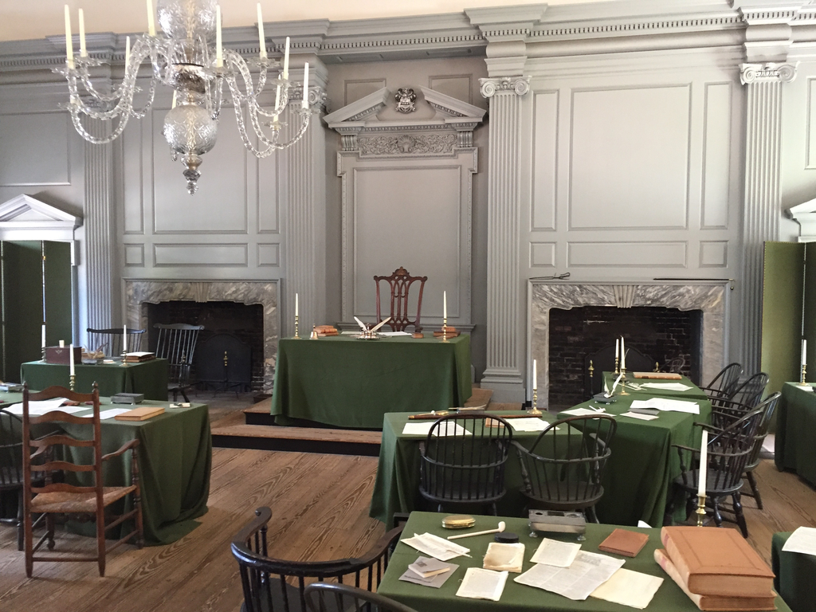

## Philosophical Influences

- The Framers were influenced by prominent philosophers who wrote about government and democracy
  - **Aristotle**: regime types
  - **John Locke**: natural rights, consent of the governed, limited government
  - **Thomas Hobbes**: the state of nature, the need for a social contract
  - **Montesquieu**: separated institutions are necessary for liberty — *“When the legislative and executive powers are united in the same person… there can be no liberty”* (*The Spirit of Laws*, 1748)

# Points of Contention

# What were some of the major disagreements that the Founders had to deal with?

## Points of Contention: Representation

### Small States vs. Large States

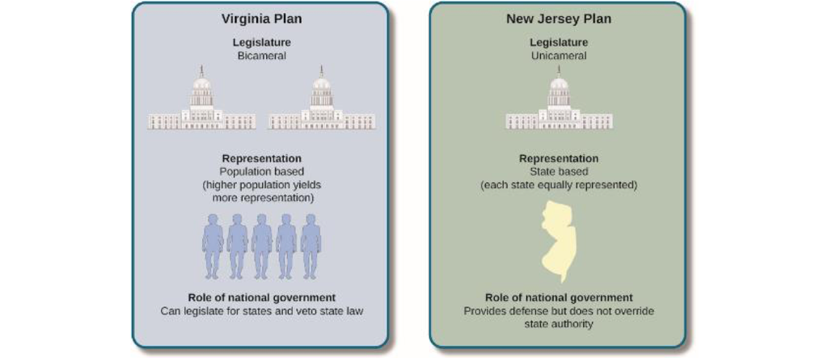

## Points of Contention: Representation

### Small States vs. Large States

| The Virginia Plan | The New Jersey Plan |
| --- | --- |
| Strong national government with three branches | Would *amend*, rather than replace, the Articles of Confederation |
| President selected by the legislature | Created a weak national government |
| Bicameral legislature | Unicameral legislature |
| At least one house elected directly by the people | Congress’s power explicitly limited, as under the Articles |

## Points of Contention: Slavery and Freedom

- Some northern states had abolished slavery
- Southern states did not want the Constitution to outlaw slavery
  - Supported southern agriculture
  - Taxed as property
  - Counted as population when determining representation

# Points of Compromise

## Representation

### The Great Compromise

- Called for a bicameral legislature in which:
  - representation in the House of Representatives would be based on each state’s population (as called for under the Virginia Plan)
  - representation in the Senate would consist of an equal number of representatives from each state (as called for under the New Jersey Plan)
  - Regarding election of legislators, the Great Compromise provided that:
    - members of the House would be elected to two-year terms by popular vote of eligible voters in each state
    - state legislatures would elect members to the Senate for six-year terms

## Slavery

### Three-Fifths Comprise

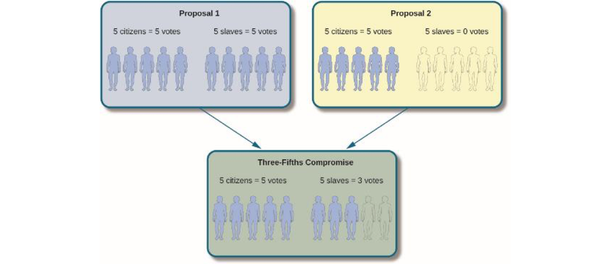

## Slavery

- Prohibited the abolition of the foreign slave trade until 1808
- Permitted the domestic slave trade
- Required states, including states that did not permit slavery, to return freedom seekers who came there for refuge

# Institutional Features

## Power and Avoiding Tyranny

- Separation of Powers
- Checks and Balances
- *Separate branches sharing power*

## Government Powers

|  | Congress | President | Courts |
| --- | --- | --- | --- |
| **Legislative** |  |  |  |
| **Executive** |  |  |  |
| **Judicial** |  |  |  |

## Government Powers

|  | Congress | President | Courts |
| --- | --- | --- | --- |
| **Legislative** | **Make Laws** |  |  |
| **Executive** |  | **Enforce and Implement Laws** |  |
| **Judicial** |  |  | **Interpret Laws** |

## Government Powers

|  | Congress | President | Courts |
| --- | --- | --- | --- |
| **Legislative** | **Make Laws** | Recommend laws, veto | Review Laws |
| **Executive** |  | **Enforce and Implement Laws** |  |
| **Judicial** |  |  | **Interpret Laws** |

## Government Powers

|  | Congress | President | Courts |
| --- | --- | --- | --- |
| **Legislative** | **Make Laws** | Recommend laws, veto, regulations | Review Laws |
| **Executive** | Override vetoes, oversight | **Enforce and Implement Laws** | Review executive branch actions |
| **Judicial** |  |  | **Interpret Laws** |

## Government Powers

|  | Congress | President | Courts |
| --- | --- | --- | --- |
| **Legislative** | **Make Laws** | Recommend laws, veto, *regulations* | Review Laws |
| **Executive** | Override vetoes, oversight | **Enforce and Implement Laws** | Review executive branch actions |
| **Judicial** | Advise and consent | Pardons, nominate judges | **Interpret Laws** |

## Federal Power vs. State Power

- Federal System: *Power is divided between the federal (or national) government and the state governments*

## Constitutional Powers

### Enumerated Powers

- *Those powers expressly mentioned in the Constitution*
  - declare war
  - impose taxes
  - coin and regulate currency
  - regulate foreign and interstate commerce
  - raise and maintain an army and a navy
  - maintain a post office
  - make treaties with foreign nations and with Native American tribes
  - make laws regulating the naturalization of immigrants

## Constitutional Powers

- **Elastic Clause**:
  - Allows Congress to pass all laws that are “necessary and proper” to carry out enumerated powers
- **Concurrent Powers**: powers shared by the national and state governments
  - *e.g., the power to tax*
- **Reserved Powers**:
  - Powers reserved for the states; *Tenth Amendment*
  - *Supremacy clause*

## Structure of the Constitution

- Preamble: *We the people*
- Article I: Legislative Branch
- Article II: Executive Branch
- Article III: Judicial Branch
- Article IV: States, Citizenship, and New States
- Article V: Amendment Process
- Article VI: Debts, Supremacy, Oaths, and Religious Tests
- Article VII: Ratification

## Amending the Constitution

### Can originate from one of two sources

- **Congress**
  - Two-thirds majority in both chambers
  - Ratified by the states
- **States**
  - Three-quarters of state legislatures, OR
  - Three-quarters of state-ratifying conventions
  - *Two-thirds of the States can petition Congress* (never used)

## Key Amendments

- **The Bill of Rights**: first ten amendments to the Constitution
- **13th, 14th, and 15th** (1865,1868,1870): abolished slavery and addressed the rights of freed slaves
- **17th** (1913): direct election of US senators
- **19th** (1920): gave women the right to vote
- **24th** (1964): eliminated poll taxes
- **26th** (1971): lowered voting age to 18

# The Federalist Papers

## The Federalist Papers

- A series of 85 essays authored by *Publius*: Alexander Hamilton, John Jay, and James Madison
- Written to persuade the citizens of **New York** — the nation’s wealthiest state, and not yet ratified — to accept the Constitution
- Nine of thirteen states ratified within nine months; **New York ratified by a vote of just 30 to 27**
- Those opposed to the Constitution were the **Anti-Federalists**
  - Concerned about a strong, central government
  - Wanted a *Declaration of rights*
  - Their pressure led directly to the Bill of Rights

## Federalist 10

- The problem of **faction**: *… a number of citizens, whether amounting to a majority or minority of the whole, who are united and actuated by some common impulse of passion, or of interest, adverse to the rights of other citizens, or to the permanent and aggregate interests of the community*
- Two ways to cure the *mischiefs of faction*:
  1. **Remove the causes** — rejected: *destroying the liberty which is essential to its existence*, or *giving to every citizen the same opinions, the same passions, and the same interests* (impossible in a free society)
  2. **Control the effects** — Madison’s actual solution, through a large **republic**
  - *“Extend the sphere, and you take in a greater variety of parties and interests”* — a large, diverse nation makes it harder for any one faction to dominate
- Republic: *a government in which the scheme of representation takes place*

## Federalist 51

- Explains the separation of powers system
- *“If men were angels, no government would be necessary. If angels were to govern men, neither external nor internal controls on government would be necessary.”*
- *Ambition must be made to counteract ambition*
- *A dependence on the people is, no doubt, the primary control on the government; but experience has taught mankind the necessity of auxiliary precautions.*

# Ratification

## The Ratification Process

### Article VII

- *The Ratification of the Conventions of nine States, shall be sufficient for the Establishment of this Constitution between the States so ratifying the Same* - Article VII, U.S. Constitution

## The Ratification Process

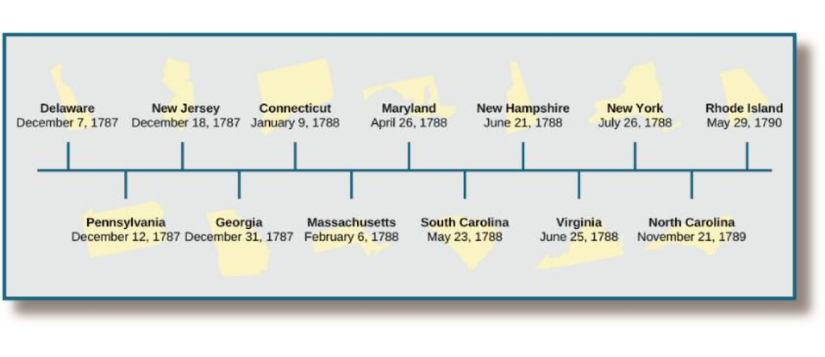